# The Influence of Vitamin C on Guinea Pigs Tooth Growth

Valerii Podymov

October 24, 2015

## Overview

The goal of this project is to analyze the [ToothGrowth](https://stat.ethz.ch/R-manual/R-devel/library/datasets/html/ToothGrowth.html) data in the R `datasets` package. The data is the result of measuring the effect of different dosage of Vitamin C on the length of teeth of 60 guinea pigs. Vitamin C was supplemented with Orange Juice and Ascorbic Acid in three different dosage, 0.5, 1.0, and 2.0 milligrams/day. The focus of the report is statistical inference around different categorizations on the length of teeth.

## Data Loading, Cleaning and Exploratory Analysis

We start with loading data from the source and performing some basic exploratory data analyses.

```r
# Load necessary libraries
library(plyr)
library(lattice)
library(datasets)
```

```r
# Load ToothGrowth data
dt <- ToothGrowth
```

To understand the content and the structure of the data we use the following two methods.

```r
# Provide a basic summary of the data
summary(dt)
```

```
##       len        supp         dose
##  Min.   : 4.20   OJ:30   Min.   :0.500
##  1st Qu.:13.07   VC:30   1st Qu.:0.500
##  Median :19.25           Median :1.000
##  Mean   :18.81           Mean   :1.167
##  3rd Qu.:25.27           3rd Qu.:2.000
##  Max.   :33.90           Max.   :2.000
```

```r
# Display the internal structure of the data.frame object
str(dt)
```

```
## 'data.frame':    60 obs. of  3 variables:
##  $ len : num  4.2 11.5 7.3 5.8 6.4 10 11.2 11.2 5.2 7 ...
##  $ supp: Factor w/ 2 levels "OJ","VC": 2 2 2 2 2 2 2 2 2 2 ...
##  $ dose: num  0.5 0.5 0.5 0.5 0.5 0.5 0.5 0.5 0.5 0.5 ...
```

Now we check if the data contain missing values.

```r
sum(is.na(dt))
```

```
## [1] 0
```

Since there are no missing values, we can continue the analysis. Next step is to change the names of variables to something more meaningful.

```r
colnames(dt) <- c("Length", "Supplement", "Dosage")
```

For further analysis we need to visualize tooth lenght against the dosage and supplement. For this purpose we first split data into subsets by

- dosages - 0.5, 1.0 and 2.0 mg/d
- supplements - orange juice (`OJ`) and ascorbic acid (`VC`)

and compute the mean average for each.

```r
# Compute summary statistics of data subsets
avg_length <- aggregate(Length ~ Dosage + Supplement, dt, mean)
```

The following chart shows that there is a strong relationship between the average teeth length and dosage.

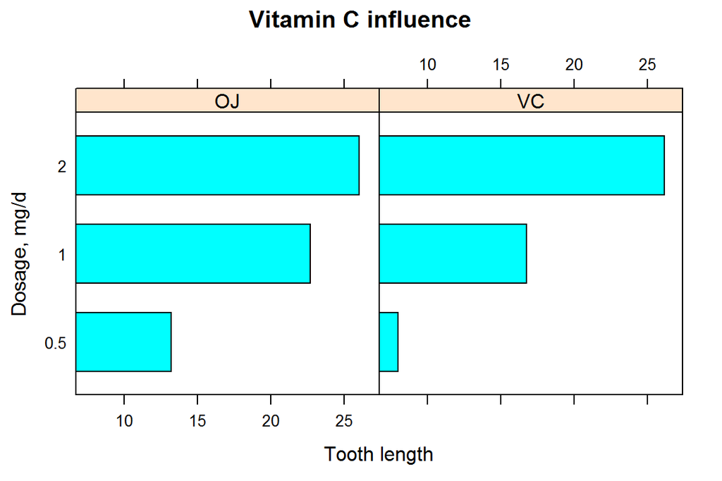

However, it is still unclear which supplement, Orange Juice `OJ` or Ascorbic Acid `VC`, has more influence on teeth growth.

## Confidence Interval Testing

In order to understand Vitamin C effect on the teeth growth, we conduct the following confidence interval testing scenarios

- Dependence of the teeth growth on the dosage
- Dependence of the teeth growth on the supplement
- Dependence of the teeth growth on different combinations of two factors

in the followng assumptions

- the data samples are independent and normally distributed
- the groups received orange juice and ascorbic acid are independent.

For each of the scenarios we subset available data appropriately and utilize the `t.test` function to determine confidence intervals.

### Dosage

Let *H0* be a null hypotesis

*H0: the increase of the dosage does not result in the average tooth length growth*

```r
# Subsetting the data set
t1 <- subset(dt, Dosage == 0.5)$Length
t2 <- subset(dt,Dosage==1.0)$Length
# Perform t-confidence interval test
t <- t.test(t1, t2, paired = FALSE, var.equal = FALSE)
t$conf.int[1:2]
```

```
## [1] -11.983781  -6.276219
```

Since the confidence interval does not contain zero we can reject the null hypothesis. In the other words, there is a positive correlation between the increase of the dosage from 0.5 to 1.0 mg/d and the average teeth length growth.

Next, if we increase the Vitamin C dosage from 1.0 to 2.0 milligrams per day, the confidence interval also does not contain zero.

```r
t1 <- subset(dt, Dosage == 1.0)$Length
t2 <- subset(dt, Dosage == 2.0)$Length
t <- t.test(t1, t2, paired = FALSE, var.equal = FALSE)
t$conf.int[1:2]
```

```
## [1] -8.996481 -3.733519
```

Consequently, we should reject the null hypothesis again.

### Type of Supplement

Let *H0* be a null hypotesis

*H0: the type of the supplement does not have an influence on the average tooth length growth*

```r
t1 <- subset(dt, Supplement == 'VC')$Length
t2 <- subset(dt, Supplement == 'OJ')$Length
t <- t.test(t1, t2, paired = FALSE, var.equal = FALSE)
t$p.value
```

```
## [1] 0.06063451
```

```r
t$conf.int[1:2]
```

```
## [1] -7.5710156  0.1710156
```

In this single test the p-value is 0.0606345 and the confidence interval contains zero, so we do not reject the null hypothesis and conclude that the type of Vitamin C supplement alone does not affect the average teeth length.

### Supplement and Dosage in Combinations

Now we compare the influence of each of the dosage of orange juice with equivalent dosage of ascorbic acid.

Let null hypotesis be

*H0: the type of the supplement with the dosage of 0.5 mg/d does not have an influence on the average tooth length growth*

```r
t1 <- subset(dt, Supplement == 'VC' & Dosage == 0.5)$Length
t2 <- subset(dt, Supplement == 'OJ' & Dosage == 0.5)$Length
t <- t.test(t1, t2, paired = FALSE, var.equal = FALSE)
t$conf.int[1:2]
```

```
## [1] -8.780943 -1.719057
```

The confidence interval does not contain zero, so we should reject the null hypothesis.

Then we check the next null hypotesis

*H0: the type of the supplement with the dosage of 1.0 mg/d does not have an influence on the average tooth length growth*

```r
t1 <- subset(dt, Supplement == 'VC' & Dosage == 1.0)$Length
t2 <- subset(dt, Supplement == 'OJ' & Dosage == 1.0)$Length
t <- t.test(t1, t2, paired = FALSE, var.equal = FALSE)
t$conf.int[1:2]
```

```
## [1] -9.057852 -2.802148
```

The confidence interval does not contain zero, so we should reject the null hypothesis.

And finally we check the null hypotesis

*H0: the type of the supplement with the dosage of 2.0 mg/d does not have an influence on the average tooth length growth*

```r
t1<-subset(dt,Supplement=='VC' & Dosage==2.0)$Length
t2<-subset(dt,Supplement=='OJ' & Dosage==2.0)$Length
t<-t.test(t1,t2,paired=FALSE,var.equal=FALSE)
t$p.value
```

```
## [1] 0.9638516
```

```r
t$conf.int[1:2]
```

```
## [1] -3.63807  3.79807
```

The confidence interval contains zero and the p-value is almost 1. Thus, we do not reject the null hypothesis and it means that with the dosage of 2.0 mg/d we cannot conclude which supplement type has a greater effect on teeth growth.

### Conclusions

- As Vitamin C dosage alone increases, the average teeth length increases as well
- Irrespective of the dosage, the supplement type alone does not affect the teeth growth
- Orange Juice affects the average teeth length greater then Ascorbic Acid with the dosage of 0.5 and 1.0 mg/d
- When the dosage reaches the value of 2.0 mg/d, there is no significant difference between Orange Juice and Ascorbic Acid